# État des lieux du réseau Santé des Jeunes

A. Moudjidath

*Rapport mis à jour le* 26 décembre 2025 à 02h49

## I. Introduction générale

Coucou à tous ceux qui lisent ce rapport

Ce projet, c’est un peu ma façon à moi de **mettre en pratique tout ce que j’ai appris pendant ma formation en SDA** et de garder une trace concrète de mes acquis parce que le cerveau, parfois, aime bien faire le tri tout seul.

L’idée m’est venue d’une question toute simple :  
*Et si on parlait de santé aux jeunes, mais sur les réseaux, à leur manière ?*

De là est née l’envie de créer un **réseau “Santé des Jeunes”**, un espace en ligne où l’on pourrait partager des contenus de prévention, des conseils simples et des informations fiables, dans un format qui donne envie d’apprendre et de participer.

Avant d’aller plus loin, j’ai voulu savoir si ce projet **intéresserait vraiment les jeunes**.  
J’ai donc réalisé un **questionnaire en ligne** destiné aux 18 ans et plus, pour comprendre :  
- leurs habitudes sur les réseaux sociaux,  
- les thèmes de santé qui les intéressent le plus,  
- et surtout, leur envie (ou non) de rejoindre un réseau dédié à la santé des jeunes.

Les résultats de ce questionnaire sont présentés dans ce rapport, qui comporte une **analyse descriptive** pour mieux comprendre qui a répondu et quelles tendances ressortent.

Ce projet fait partie de mon parcours de validation en formation SDA.  
Et si tu fais partie de ceux qui ont pris le temps de répondre au questionnaire, **MERCI BEAUCOUP**.  
Par contre, si tu tombes sur ce rapport sans l’avoir encore fait, tu peux encore participer ici :

[Remplir le questionnaire Santé des Jeunes](https://forms.gle/hjdtQCREu2CjzEwF8)

## II. Analyse descriptive

Avant de plonger dans les chiffres, prenons un petit moment pour découvrir qui sont les jeunes qui ont participé à ce questionnaire.

### Section 1 : Profil et informations démographiques

#### 1. Répartition par âge

Surprise ou pas ?

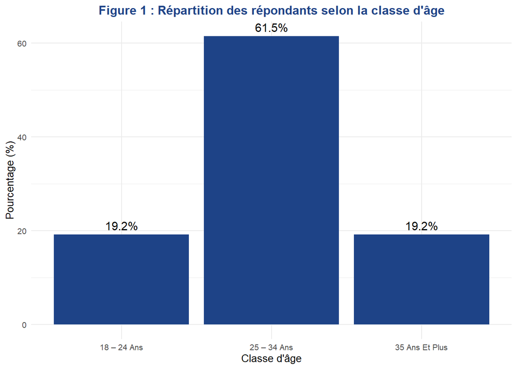

La grande majorité des répondants sont des jeunes adultes entre **25 et 34 ans**, avec pourcentage de **61.5** ! On est pile dans la cible du projet “Santé des Jeunes”.

#### 2. Répartition par sexe

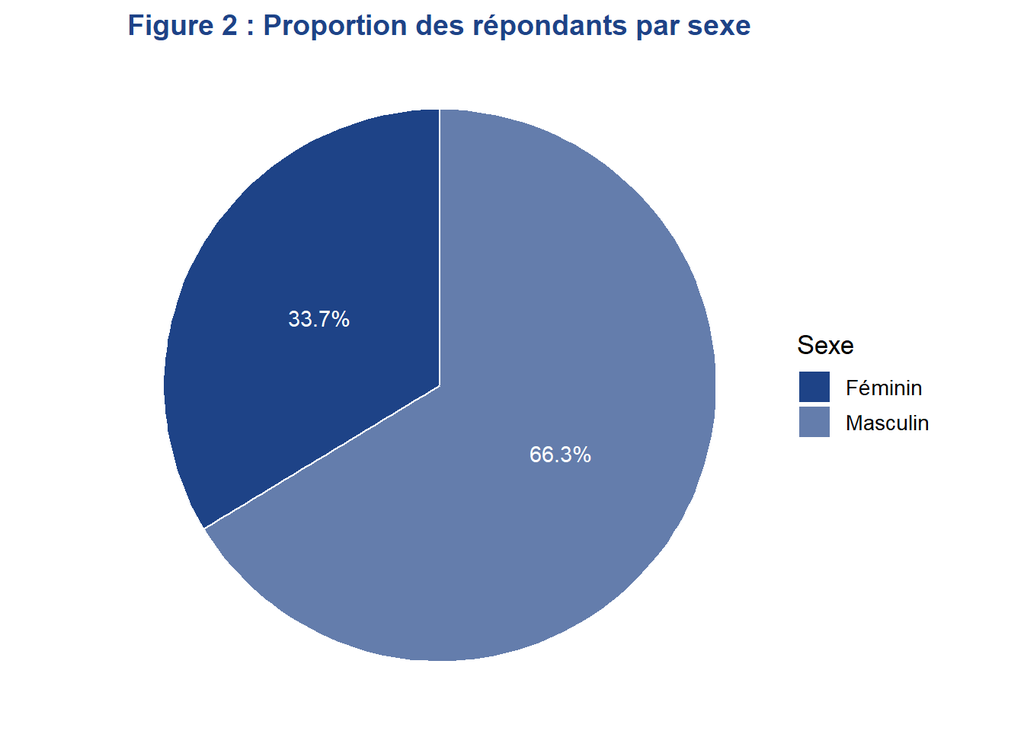

#### 3. Répartition par pays de résidence

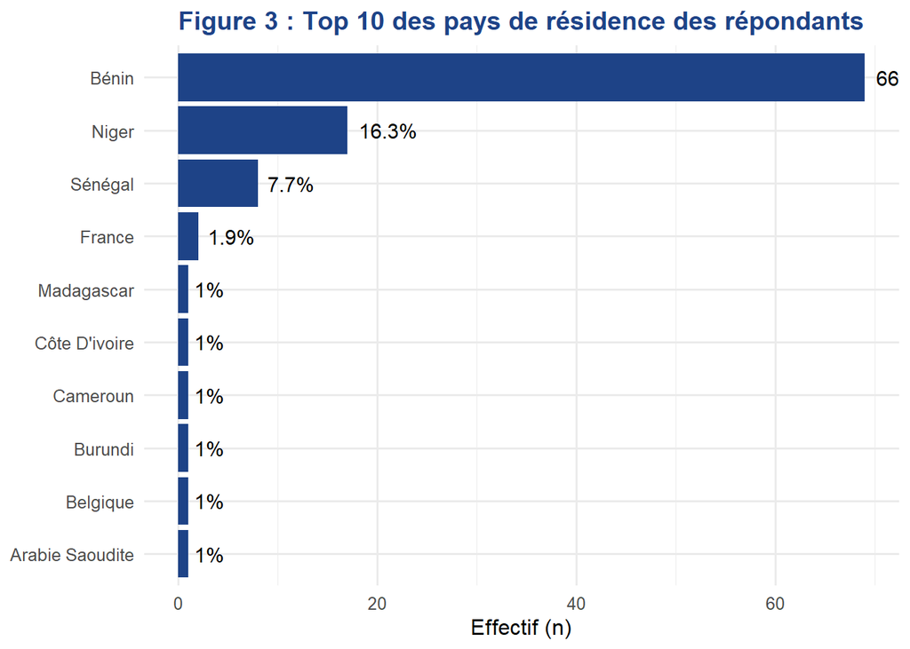

#### 4. Répartition par occupation

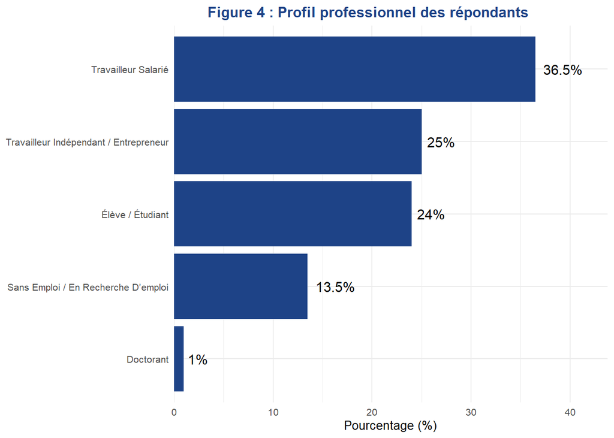

### Section 2 : Usage du numérique

#### 1. Fréquence d’utilisation des réseaux sociaux

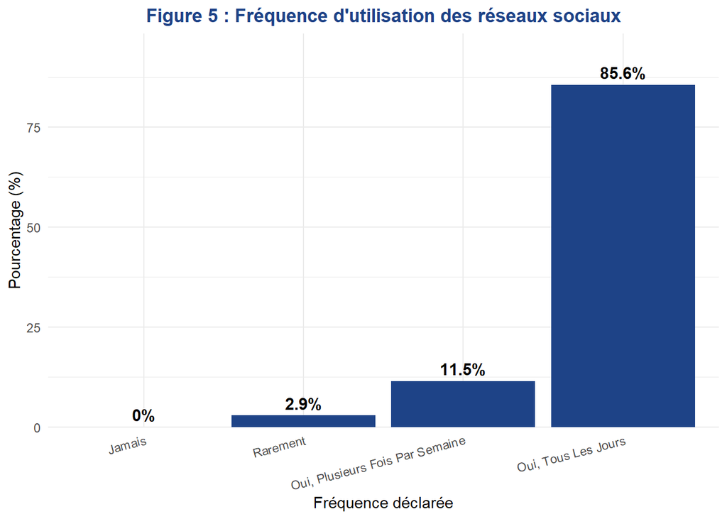

#### 2. Les plateformes utilisées

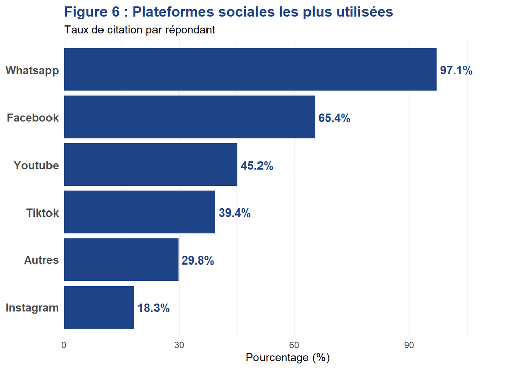

### Section 3 : Connaissances santé

#### 1. Les maladies les mieux connues

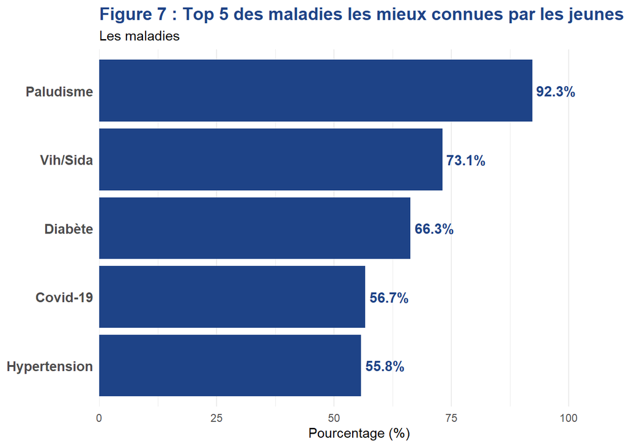

#### 2. Les principaux obstacles à la santé

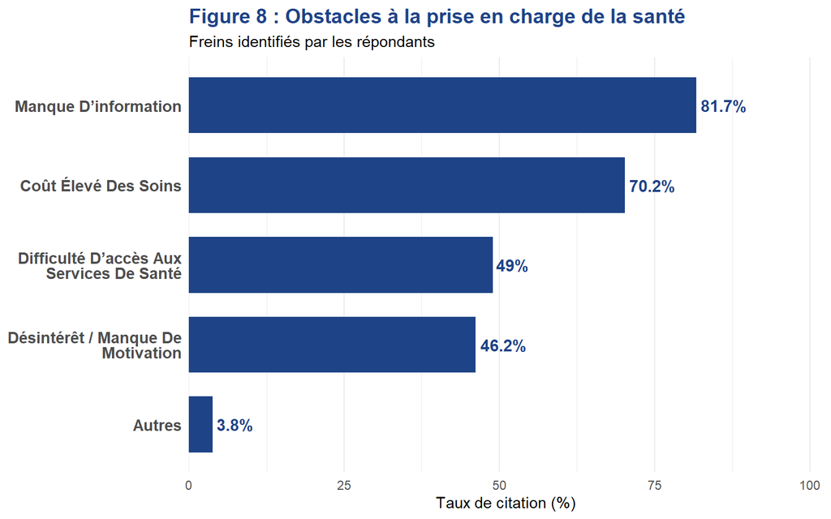

### Section 4 : Intérêt & préférences

#### 1. Intérêt pour la sensibilisation

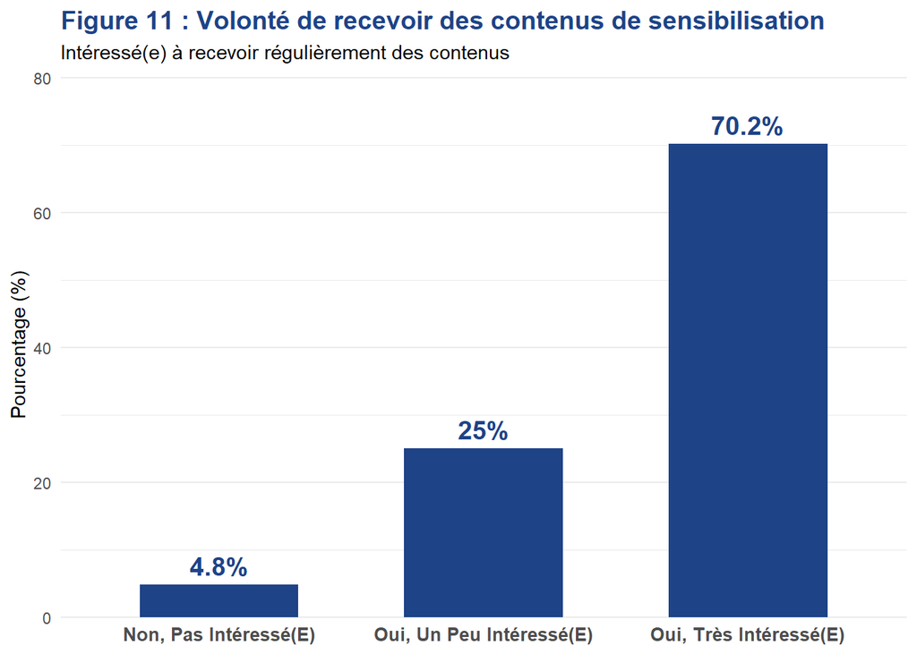

#### 2. Formats de contenu préférés

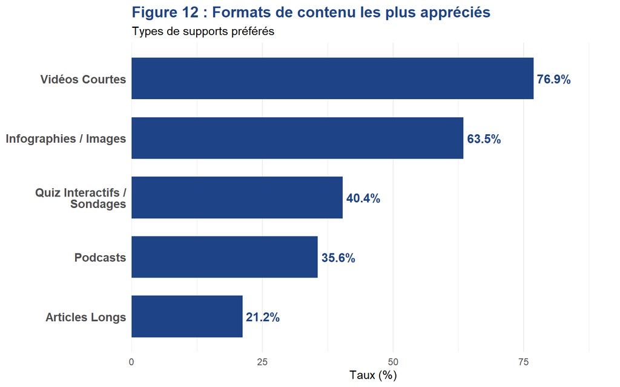

#### 3. Les thèmes de santé

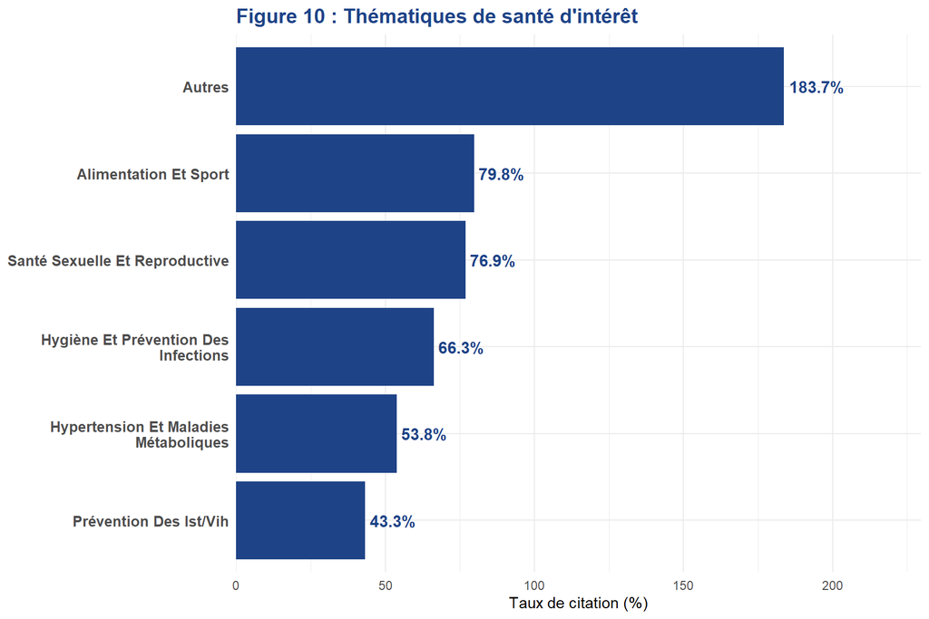

### Section 4 : Engagement & idées

#### 1. Participation active

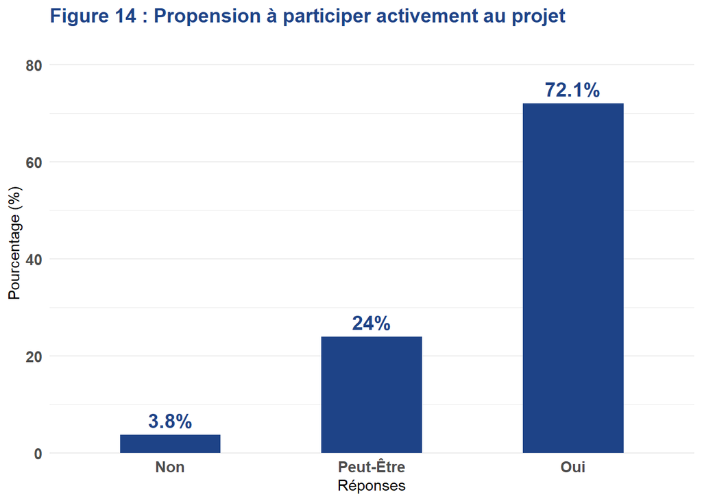

#### 2. Analyse des suggestions de sensibilisation

L’analyse des réponses montre que pour réussir à sensibiliser les jeunes, il faut arrêter les longs discours et adopter leurs propres codes de communication. Les participants conseillent d’utiliser des formats très courts et visuels comme des vidéos en boucle ou des “stories” animées, diffusées de préférence le matin pour capter l’attention. Ils suggèrent de rendre le contenu interactif et amusant par des challenges ou des récompenses, tout en faisant appel à des visages familiers comme des influenceurs ou des artistes. Enfin, ils insistent sur l’importance d’une approche solidaire et inclusive qui ne délaisse pas les zones rurales, afin que chaque jeune, quel que soit son lieu de vie, se sente acteur de sa propre santé plutôt que simple spectateur.